# Election 2020 Simulation (Uninformative vs. Informative Prior)

Mahmoud Abu Ghzalah

2/16/2021

## Did Trump have more support than Biden in 2020?

First use an uninformative prior, here set all shape parameters in the dirichlet distrubtion = 1

Data is sourced from a 2020 Qunnipiac University National poll of 1426 self identified likely voters

Link: https://poll.qu.edu/images/polling/us/us10222020_udxf16.pdf

Create a table to store the proportions of voters

```r
(voter_prop <- tibble("Biden" = 0.51, "Trump" = 0.41,
                     "Other" = 0.02, "No_Opinion" = 0.06))
```

```
## # A tibble: 1 x 4
##   Biden Trump Other No_Opinion
##   <dbl> <dbl> <dbl>      <dbl>
## 1  0.51  0.41  0.02       0.06
```

Create a table to store the number of likely voters in each category

```r
# Variable to store number of respondents to poll
voter_sample <- 1426
```

Multiply sample size by proportions to get counts for each category

```r
(voter_count <- voter_sample * voter_prop)
```

```
##    Biden  Trump Other No_Opinion
## 1 727.26 584.66 28.52      85.56
```

Voters in each category are not integers. I’ll round them to the nearest whole number

```r
(voter_count <- map_dbl(voter_count, round, digits = 0))
```

```
##      Biden      Trump      Other No_Opinion
##        727        585         29         86
```

We have an extra observation compared to the sample size, not sure what the implication of this would be.

If there’s a more elegant solution, let me know.

Use the vector of voter counts to simulate 10,000 draws from the posterior Dirichlet distribution with an uninformative prior

```r
# Set seed for reproducibility
set.seed(12345)

# Simulate 10,000 draws from posterior distribution
sim_1 <- rdirichlet(10000, alpha = voter_count)
head(sim_1)
```

```
##           [,1]      [,2]       [,3]       [,4]
## [1,] 0.5092457 0.4128047 0.01915205 0.05879761
## [2,] 0.5187319 0.3968873 0.01772457 0.06665617
## [3,] 0.5038471 0.4185461 0.02210511 0.05550170
## [4,] 0.4897556 0.4275772 0.02662283 0.05604433
## [5,] 0.5254194 0.3901732 0.01377786 0.07062951
## [6,] 0.5077789 0.4158961 0.01966862 0.05665631
```

What is the probability Trump had more support than Biden? ie: $\alpha_2 + y_2 > \alpha_1 + y_1$

```r
hypo_1 <- sim_1[, 2] - sim_1[, 1]
```

# Plot distribution of the hypothesis:

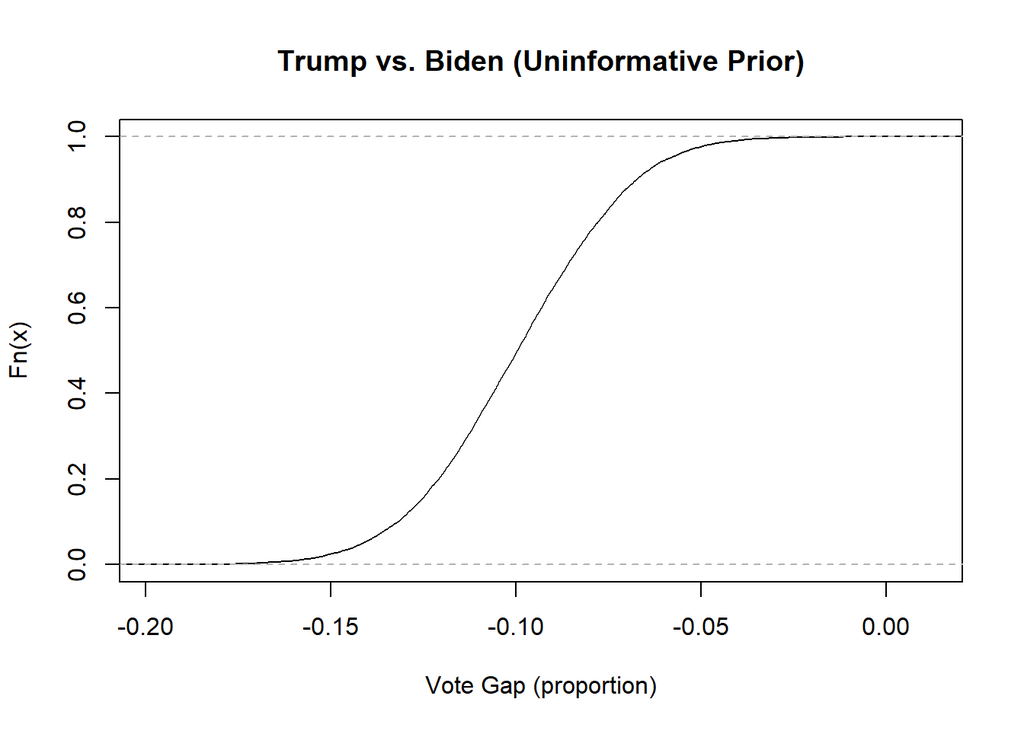

```r
plot(ecdf(hypo_1), xlab = 'Vote Gap (proportion)', main = "Trump vs. Biden (Uninformative Prior)")
```

It’s pretty unlikely that Trump had more support than Biden according to our simulation

Find the probability Trump had more support than Biden by counting the proportion of elements in hypo_1 that are greater than 0, this is the number of simulated elections in which Trump had more support than Biden

```r
length(hypo_1[hypo_1 > 0]) / length(hypo_1)
```

```
## [1] 0
```

There wasn’t a single simulation using the uninformative prior in which Trump would have had more support than Biden

I’ll now use an informative prior - we’ll adjust the shape parameters of the prior to reflect voter preferences from the 2016 Trump v. Clinton election

I begin by creating a table to store voter preferences from the 2016 election

Using data sourced from the Federal Elections Committee: https://www.fec.gov/documents/1889/federalelections2016.pdf

Trump received 46.09% of the popular vote

```r
informative_prior <- tibble("Trump" = 0.4609,
                            "Clinton" = 0.488, "Other" = 5.73)
```

I adjust the number of categories from the 2020 election poll by combining “No opinion” and “other” into one category

```r
voter_prop <- voter_prop %>% mutate(
  "Neither" = No_Opinion + Other) %>%
  select(-c(No_Opinion, Other))

voter_prop
```

```
## # A tibble: 1 x 3
##   Biden Trump Neither
##   <dbl> <dbl>   <dbl>
## 1  0.51  0.41    0.08
```

```r
# Combine categories in the voter_count vector
voter_count <- c(voter_count[1:2], voter_count[3] + voter_count[4])
```

Apply the informative prior to the number of likely voters to calculate alphas (shape parameters of the Dirichlet posterior)

```r
(alpha_params <- informative_prior * voter_sample)
```

```
##      Trump Clinton   Other
## 1 657.2434 695.888 8170.98
```

Create vector that contains parameters of posterior Dirichlet distribution by summing alpha parameter and 2020 poll responses

```r
# Convert post_params from a tibble to a vector
(post_params <- (alpha_params + voter_count) %>% slice(1) %>% as.numeric())
```

```
## [1] 1384.243 1280.888 8285.980
```

Simulate 10,000 draws from the posterior distribution using the informative prior

```r
sim_2 <- rdirichlet(10000, alpha = post_params)
head(sim_2)
```

```
##           [,1]      [,2]      [,3]
## [1,] 0.1180278 0.1178493 0.7641228
## [2,] 0.1283641 0.1144682 0.7571677
## [3,] 0.1229803 0.1169853 0.7600344
## [4,] 0.1262908 0.1145162 0.7591930
## [5,] 0.1258460 0.1183976 0.7557564
## [6,] 0.1251418 0.1190741 0.7557841
```

What is the probability Trump had more support than Biden?

ie: $\alpha_2 + y_2 > \alpha_1 + y_1$

```r
hypo_2 <- sim_2[, 2] - sim_2[, 1]
```

Plot cumulative distribution of the vote gap between Biden and Trump

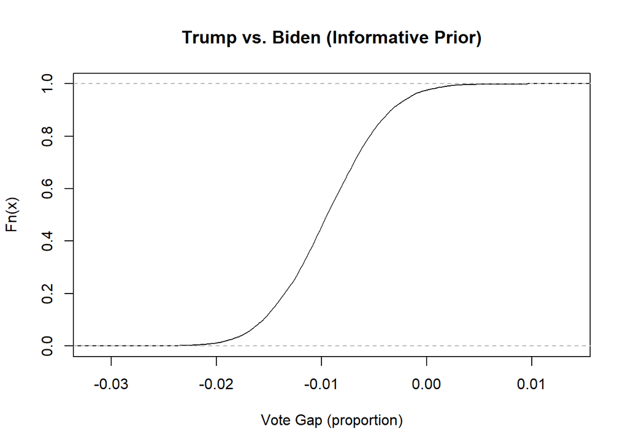

```r
plot(ecdf(hypo_2), xlab = 'Vote Gap (proportion)', main = "Trump vs. Biden (Informative Prior)")
```

Number of simulated elections where Trump wins more votes than Biden

```r
length(hypo_2[hypo_2 > 0])
```

```
## [1] 239
```

```r
# Find porportion to obtain probability

length(hypo_2[hypo_2 > 0]) / length(hypo_2)
```

```
## [1] 0.0239
```

The probability that Trump secures more votes than Biden among likely voters is now 2.39% using the informative prior

Distribution of the predicted vote gap using informative prior:

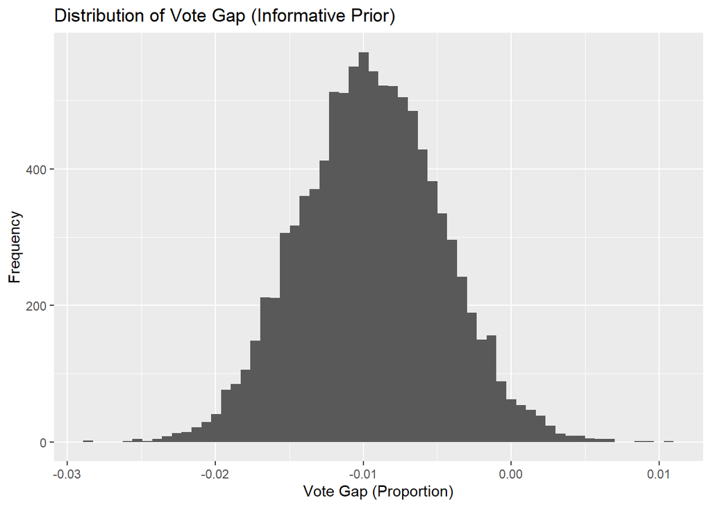

```r
hypo_2 %>% tibble() %>% ggplot() +
  geom_histogram(aes(x = hypo_2), bins = 60) +
  labs(x = "Vote Gap (Proportion)", y = "Frequency", title = "Distribution of Vote Gap (Informative Prior)")
```

Distribution of the predicted vote gap using an uninformative prior:

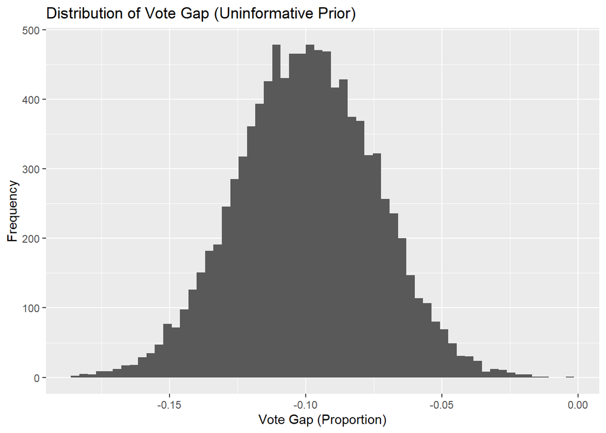

```r
hypo_1 %>% tibble() %>% ggplot() +
  geom_histogram(aes(x = hypo_1), bins = 60) +
  labs(x = "Vote Gap (Proportion)", y = "Frequency", title = "Distribution of Vote Gap (Uninformative Prior)")
```

Overlay the two distributions using a frequency polygon

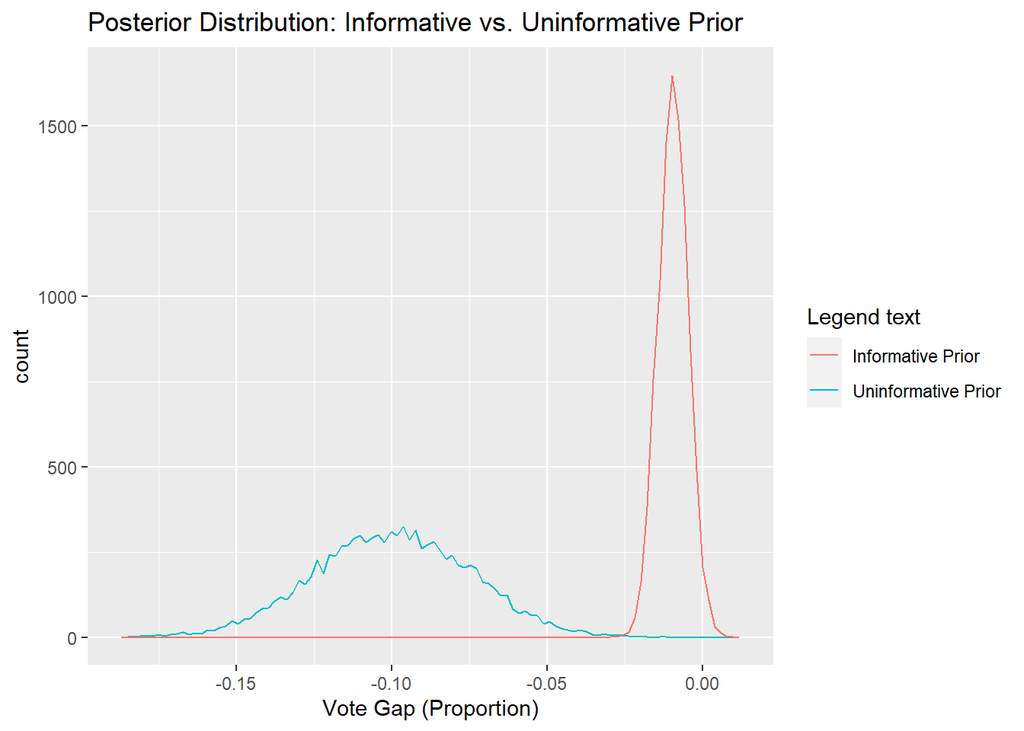

```r
ggplot() +
  geom_freqpoly(data = tibble(hypo_1), aes(x = hypo_1, colour = "Uninformative Prior"), bins = 100) +
  geom_freqpoly(data = tibble(hypo_2), aes(x = hypo_2, colour = "Informative Prior"), bins = 100) +
  labs(color = "Legend text", title = "Posterior Distribution: Informative vs. Uninformative Prior", x = "Vote Gap (Proportion)")
```